# Group13 : IML Assignment

HABIMANA Martin, Jovanie nkouakep, TURIKUMWE jean Claude, Arcange Djovani Bitsindou

2024-04-05

### Required packages

```r
library(sp)
library(xts)
library(mlr3)
library(mlr3learners)
library(mlr3tuning)
```

```r
library(readr)
library(paradox)
library(OpenML)
library(mlr3pipelines)
library(future)
library(ggplot2)
# install.packages("splitTools")
library(splitTools)
library(CASdatasets)
```

## Introduction

This report addresses the task of estimating the technical price, focusing on predicting claim amounts given exposure equals 1. We employ machine learning techniques on a dataset to achieve this, aiming for accurate predictions while ensuring the interpretability of the final model.

### Main objective

To train an algorthm/model that predict the claim amounts given claimInd differ to zero when exposure equals to one.

### Methodology

1.Data Preprocessing 2.Split dataset into train (80%) and test (20%) dataset. 3.Model Creation 4.Model Prediction 5.Model Evaluation

# 1.Data processing

### Loading data

```r
data(freMPL4)
```

### Data cleaning

Removing unnecessary variables in dataset with date data type.

```r
freMPL4 <- subset( freMPL4 , select = -DeducType )
freMPL4 <- subset( freMPL4 , select = -RecordEnd )
freMPL4<- subset(freMPL4, select = -RecordBeg)
head(freMPL4)
```

```
##   Exposure LicAge VehAge Gender MariStat SocioCateg               VehUsage
## 1    0.583    579    10+   Male    Other      CSP60                Private
## 2    0.416    361      1 Female    Other       CSP1           Professional
## 3    0.583    366      2 Female    Other       CSP1           Professional
## 4    0.200    187      0   Male    Alone      CSP55 Private+trip to office
## 5    0.083    169      1 Female    Other       CSP1           Professional
## 6    0.375    170      1 Female    Other       CSP1           Professional
##   DrivAge HasKmLimit BonusMalus        VehBody VehPrice
## 1      83          0         50          sedan        N
## 2      55          0         58          sedan        D
## 3      55          0         72          sedan        D
## 4      34          0         80       microvan        K
## 5      33          0         63 other microvan        L
## 6      34          0         63 other microvan        L
##                      VehEngine VehEnergy  VehMaxSpeed VehClass RiskVar
## 1                    injection   regular 190-200 km/h        H      14
## 2                    injection   regular 160-170 km/h        B      15
## 3                    injection   regular 160-170 km/h        B      15
## 4 direct injection overpowered    diesel 170-180 km/h       M1      20
## 5 direct injection overpowered    diesel 170-180 km/h       M1      17
## 6 direct injection overpowered    diesel 170-180 km/h       M1      17
##   ClaimAmount         Garage ClaimInd
## 1           0           None        0
## 2           0           None        0
## 3           0           None        0
## 4           0           None        0
## 5           0           None        0
## 6           0 Private garage        0
```

### ClaimInd (0 and 1) proportion and plot of it

```r
t<-table(freMPL4$ClaimInd)
t
```

```
##
##     0     1
## 35933   362
```

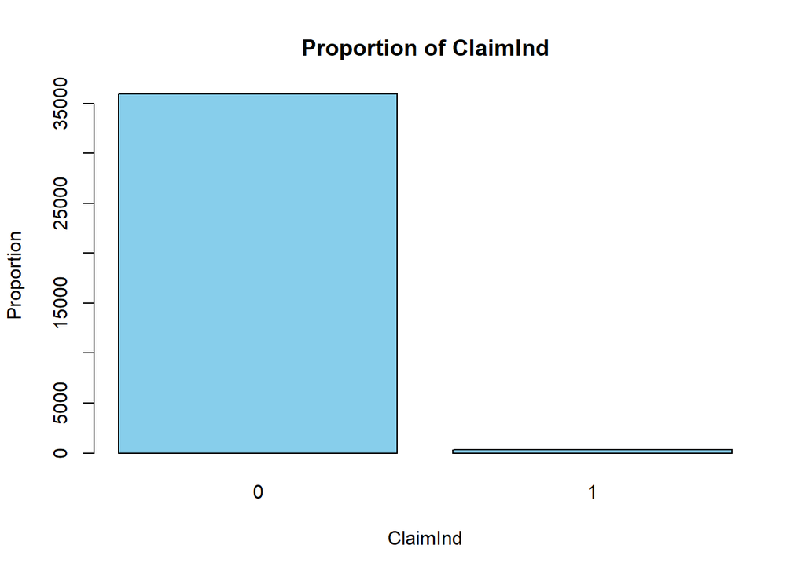

```r
barplot(t, main = "Proportion of ClaimInd", xlab = "ClaimInd", ylab = "Proportion", col = "skyblue")
```

As it is shown on the plot, we have very few claims(1) compared to those who did not complain (0).

# 2.Split dataset into train (80%) and test (20%) dataset.

### Train and test have the same claim frequency

```r
set.seed(2024)
ind <- partition(freMPL4$ClaimInd, p = c(train = 0.8, test = 0.2))
train <- freMPL4[ind$train, ]
test <- freMPL4[ind$test, ]
head(train)
```

```
##   Exposure LicAge VehAge Gender MariStat SocioCateg     VehUsage DrivAge
## 1    0.583    579    10+   Male    Other      CSP60      Private      83
## 2    0.416    361      1 Female    Other       CSP1 Professional      55
## 3    0.583    366      2 Female    Other       CSP1 Professional      55
## 5    0.083    169      1 Female    Other       CSP1 Professional      33
## 6    0.375    170      1 Female    Other       CSP1 Professional      34
## 7    0.500    224      3   Male    Other      CSP47 Professional      53
##   HasKmLimit BonusMalus        VehBody VehPrice                    VehEngine
## 1          0         50          sedan        N                    injection
## 2          0         58          sedan        D                    injection
## 3          0         72          sedan        D                    injection
## 5          0         63 other microvan        L direct injection overpowered
## 6          0         63 other microvan        L direct injection overpowered
## 7          0         72            van        L direct injection overpowered
##   VehEnergy  VehMaxSpeed VehClass RiskVar ClaimAmount         Garage ClaimInd
## 1   regular 190-200 km/h        H      14           0           None        0
## 2   regular 160-170 km/h        B      15           0           None        0
## 3   regular 160-170 km/h        B      15           0           None        0
## 5    diesel 170-180 km/h       M1      17           0           None        0
## 6    diesel 170-180 km/h       M1      17           0 Private garage        0
## 7    diesel 140-150 km/h        0      19           0           None        0
```

```r
head(test)
```

```
##    Exposure LicAge VehAge Gender MariStat SocioCateg               VehUsage
## 4     0.200    187      0   Male    Alone      CSP55 Private+trip to office
## 11    0.249    241      5 Female    Other      CSP55 Private+trip to office
## 13    0.750    298      2   Male    Other      CSP50 Private+trip to office
## 19    0.499    469    10+   Male    Other       CSP1           Professional
## 25    0.025    427      4 Female    Other      CSP42       Professional run
## 29    1.000    667      5   Male    Other      CSP60                Private
##    DrivAge HasKmLimit BonusMalus        VehBody VehPrice
## 4       34          0         80       microvan        K
## 11      39          0         54          sedan        B
## 13      43          0         76 other microvan        M
## 19      58          0         50  station wagon        T
## 25      55          0         50          sedan        J
## 29      81          0         91          sedan        L
##                       VehEngine VehEnergy  VehMaxSpeed VehClass RiskVar
## 4  direct injection overpowered    diesel 170-180 km/h       M1      20
## 11                    injection   regular 150-160 km/h        A      19
## 13                    injection   regular 190-200 km/h       M2      10
## 19                    injection   regular 200-220 km/h        H       8
## 25                    injection    diesel 160-170 km/h       M2      14
## 29                    injection   regular 200-220 km/h       M2      17
##    ClaimAmount            Garage ClaimInd
## 4            0              None        0
## 11           0              None        0
## 13           0              None        0
## 19           0 Collective garage        0
## 25           0              None        0
## 29           0              None        0
```

### Define and filter out the specific row indices to be predicted or estimated.

```r
row_indices<-c(11386, 12286, 2119, 2238, 27833, 27988)
rowtopredict<-freMPL4[row_indices,]
j<-freMPL4[row.names(freMPL4) %in% row_indices, ]
head(j)
```

```
##       Exposure LicAge VehAge Gender MariStat SocioCateg               VehUsage
## 2119     0.001    483      0   Male    Other       CSP1 Private+trip to office
## 2238     0.083    294    8-9   Male    Other      CSP46           Professional
## 11386    0.666    348      4   Male    Other      CSP46           Professional
## 12286    0.166    678      1   Male    Other      CSP60                Private
## 27833    0.692     18      0 Female    Alone      CSP26 Private+trip to office
## 27988    0.678    361      0   Male    Other      CSP49       Professional run
##       DrivAge HasKmLimit BonusMalus        VehBody VehPrice
## 2119       58          0         60 other microvan        P
## 2238       43          0         50          sedan        K
## 11386      47          0         51            van        F
## 12286      82          0         50          sedan        J
## 27833      21          0        100          sedan        H
## 27988      48          0         50            van        H
##                          VehEngine VehEnergy  VehMaxSpeed VehClass RiskVar
## 2119  direct injection overpowered    diesel 180-190 km/h        H       5
## 2238                     injection   regular 190-200 km/h        H      15
## 11386                    injection   regular 140-150 km/h       M1      15
## 12286                    injection   regular 200-220 km/h       M1      17
## 27833                    injection   regular 150-160 km/h        B      17
## 27988 direct injection overpowered    diesel 140-150 km/h       M1       6
##       ClaimAmount         Garage ClaimInd
## 2119            0 Private garage        0
## 2238            0           None        0
## 11386           0           None        0
## 12286           0           None        0
## 27833           0           None        0
## 27988           0           None        0
```

# 3.Model Creation

## 1. ClaimInd classification model

### Define task for classification model for training and testing data

```r
train$ClaimInd <- as.factor(train$ClaimInd)
task1 <- TaskClassif$new("train", backend = train, target = "ClaimInd")

test$ClaimInd <- as.factor(test$ClaimInd)
task <- TaskClassif$new("test", backend = test, target = "ClaimInd")
head(task$data())
```

```
##    ClaimInd BonusMalus ClaimAmount DrivAge Exposure            Garage Gender
##      <fctr>      <int>       <num>   <int>    <num>            <fctr> <fctr>
## 1:        0         80           0      34    0.200              None   Male
## 2:        0         54           0      39    0.249              None Female
## 3:        0         76           0      43    0.750              None   Male
## 4:        0         50           0      58    0.499 Collective garage   Male
## 5:        0         50           0      55    0.025              None Female
## 6:        0         91           0      81    1.000              None   Male
##    HasKmLimit LicAge MariStat RiskVar SocioCateg VehAge        VehBody VehClass
##         <int>  <int>   <fctr>   <int>     <fctr> <fctr>         <fctr>   <fctr>
## 1:          0    187    Alone      20      CSP55      0       microvan       M1
## 2:          0    241    Other      19      CSP55      5          sedan        A
## 3:          0    298    Other      10      CSP50      2 other microvan       M2
## 4:          0    469    Other       8       CSP1    10+  station wagon        H
## 5:          0    427    Other      14      CSP42      4          sedan       M2
```

[output cut: 17 more lines]

Define learner, train and predict on test dataset using classif,glmnet with paramter s and alpha.

```r
learner = lrn("classif.glmnet", s= to_tune(0, 1), alpha=to_tune(0,1),predict_type='prob')

learner_class <- as_learner(po("encode", method = "treatment", affect_columns = selector_type("factor"), id="bynary_enc") %>>% po("scale")%>>% learner)

graph <- auto_tuner(
  learner = learner_class,
  tuner = tnr("grid_search", batch_size = 5),
  resampling = rsmp("cv", folds = 3),
  measure = msr("classif.ce"),
  terminator = trm("evals", n_evals=3)
)

graph$train(task1)
```

[output not shown]

```
## INFO  [11:23:31.155] [mlr3] Finished benchmark
## INFO  [11:23:31.378] [bbotk] Result of batch 1:
## INFO  [11:23:31.385] [bbotk]  classif.glmnet.s classif.glmnet.alpha  classif.ce warnings errors
## INFO  [11:23:31.385] [bbotk]         0.0000000            1.0000000 0.009953491        0      0
## INFO  [11:23:31.385] [bbotk]         0.1111111            0.2222222 0.009643510        0      0
## INFO  [11:23:31.385] [bbotk]         0.2222222            0.4444444 0.009953491        0      0
## INFO  [11:23:31.385] [bbotk]         0.3333333            0.8888889 0.009953491        0      0
## INFO  [11:23:31.385] [bbotk]         0.4444444            0.3333333 0.009953491        0      0
## INFO  [11:23:31.385] [bbotk]  runtime_learners                                uhash
## INFO  [11:23:31.385] [bbotk]            199.15 ad2cc624-ef7a-46b0-a6b1-e2fd74b89005
## INFO  [11:23:31.385] [bbotk]             18.92 2afc93d8-7e2c-4877-9884-702f5cc7f6f4
## INFO  [11:23:31.385] [bbotk]             20.26 b41251f7-ae80-4d82-b347-407510535b71
## INFO  [11:23:31.385] [bbotk]            169.27 04806449-b6d2-4168-8a40-e4c0e6915fa9
## INFO  [11:23:31.385] [bbotk]             28.22 d6607f1e-c25f-4d91-8fb6-8f52924fdb53
## INFO  [11:23:31.397] [bbotk] Finished optimizing after 5 evaluation(s)
## INFO  [11:23:31.398] [bbotk] Result:
## INFO  [11:23:31.404] [bbotk]  classif.glmnet.s classif.glmnet.alpha learner_param_vals  x_domain classif.ce
## INFO  [11:23:31.404] [bbotk]             <num>                <num>             <list>    <list>      <num>
## INFO  [11:23:31.404] [bbotk]         0.1111111            0.2222222          <list[5]> <list[2]> 0.00964351
```

```r
prd<-graph$predict(task)

acc<-prd$score((msr("classif.acc")))

cat("The accuracy of classification model using glmnet as a learner is:", acc)
```

```
## The accuracy of classification model using glmnet as a learner is: 0.9899449
```

```r
task$rbind(j)
```